# Etwas R am Abend

Norman Markgraf

21.11.2016

# Was ist eigentlich R?

**Programmiersprache S**:

- Von Bell Labs für Statistik, Simulation, Grafik entwickelt (Becker and Chambers; 1984)
- kommerzielle Implementation: **S-PLUS**

**Programmiersprache R**:

- Implementation unter GPL (GNU General Public License), offener Quellcode
- **Vorteile:**
  - interpretierter Programmcode, objektorientiert
  - leicht erweiterbar durch eigene Routinen, Pakete, DLLs
  - viele Grafikmöglichkeiten
  - standardisiertes, einfach handhabbares Datenformat (data.frame)
  - gut durchdachtes Format zur Anpassung von (Regressions-)Modellen

# Was ist eigentlich R?

**Programmiersprache R**:

- **Vorteile (Forts.):**
  - aktive Entwicklergruppe, hilfreiche Mailingliste
  - modularer Aufbau mit mehr als 8000 Erweiterungspaketen
  - man kann ansprechende Diagramme und interaktive Apps entwickeln (z.B. [plotly](https://plot.ly/r/), [shiny](http://shiny.rstudio.com)).
  - führende Plattform für statistische Analysen
- **Nachteile:**
  - bisher keine echte “Standard”-GUI (aber es gibt ja RStudio)
  - verfügbare Routinen/Pakete manchmal unübersichtlich

# Wer nutzt R im echten Leben?

Unternehmen, die „ernsthaft“ Daten analysieren, setzen häufig auf R.

[figure not shown]

Wer nutzt R

**Quelle:** http://www.revolutionanalytics.com/companies-using-r

Falls Sie gerne **Werbevideos** ansehen, hier ein Link https://www.youtube.com/watch?v=TR2bHSJ_eck

# Einfach nur R oder darf es etwas mehr sein?

**R** ist ein eine *komandozeilenorientierte*-Sprache!

```r
1+1
```

```
## [1] 2
```

```r
1+2*3^4
```

```
## [1] 163
```

```r
x <- 1; y <- 2
x+y
```

```
## [1] 3
```

# Einfach nur R oder darf es etwas mehr sein?

Die mit unter recht schnell schöne Ergebnisse produzieren kann:

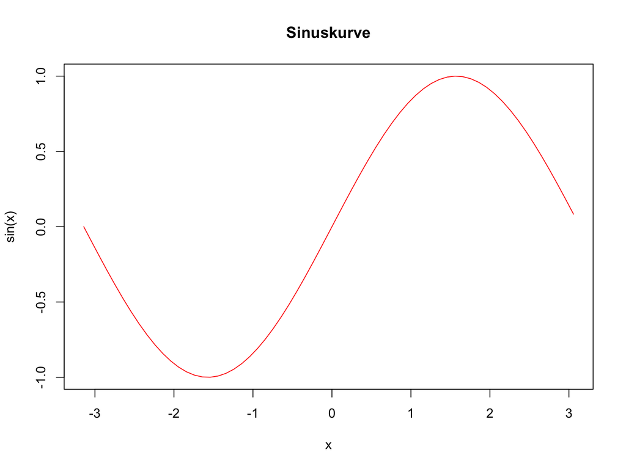

```r
x <- seq(-pi,pi,by=0.1)
plot(x, sin(x),  type="l", col="red",
     main="Sinuskurve")
```

.

# Einfach nur R oder darf es etwas mehr sein?

Natürlich können Sie **R** als Programmiersprache direkt von der Konsole aus füttern.

Besser ist es aber seine Skripte vorab mit Hilfe eines Texteditors zu schreiben und R dieses ausführen zu lassen.

Noch besser ist die Nutzung von Integrierten Entwicklungsumgebenung (*IDE*), wie z.B.

- [RStudio](https://www.rstudio.com)
- [Rcmdr](http://www.rcommander.com)
- [StatET for R](http://www.walware.de/goto/statet)  
  eine auf [Eclipse](http://www.eclipse.org/eclipse/) basierende IDE für R
- [ESS](http://ess.r-project.org) ein add-on package für GNU Emacs und XEmacs

# Was bekommt man wo und wie?

**Empfehlung:**

- **R** (3.3.2) , RStudio (0.99.903 oder neuer als 1.0.44) (vergessen Sie lieber den **R-Cmdr**)
  - **R** finden Sie hier: https://cran.rstudio.com oder https://www.r-project.org
  - Aktuell ist die Version 3.3.2
  - **Achtung MAC-Nuzter!!!**: Sie benötigen zusätlich erst noch XQuartz.
    - XQuartz finden Sie hier: https://www.xquartz.org
- **RStudio** (Desktop-Version) (1.0.44, leider!)
  - Die aktuelle Version finden Sie hier: https://www.rstudio.com/products/rstudio/download/
  - **Besser** ist aber die alte Version 0.99.903 von hier: https://support.rstudio.com/hc/en-us/articles/206569407-Older-Versions-of-RStudio
  - Oder, für mutige, die tagesaktuelle Entwicklerversion von hier: https://dailies.rstudio.com

# Die Installation

- Die wichtigsten Schritte bei der Installation:
  - Abwarten und bestätigen ;-)

# Die wichtigsten Pakete und wie man sie installiert

Im Allgemeinen instaliert man ein Paket durch den Befehl:

```r
install.packages("<blubber>", dependencies=TRUE)
```

Für einen guten Start sollte man folgende Pakete installieren:

- **tidyverse**

  **tidyverse** ist eine Sammlung von Paketen, die einem den Umgang mit **R** und *Grafik* erleichtern.

  Das sind u.a. die Pakete:
  - [ggplot2](http://ggplot2.org) # DAS Grafikpaket von *R*
  - [dplyr](https://cran.rstudio.com/web/packages/dplyr/vignettes/introduction.html) # Das Paket zur Daten manipulation
  - [readr](https://blog.rstudio.org/2016/08/05/readr-1-0-0/) # Das Paket zum Einlesen von Daten

# Die wichtigsten Pakete und wie man sie installiert

- **mosaic**

  Mehr Informationen zu **mosaic** finden Sie hier:
  - [Project MOSAIC](http://mosaic-web.org)
  - [Less Volume, More Creativity – Getting Started with the mosaic Package](https://cran.r-project.org/web/packages/mosaic/vignettes/LessVolume-MoreCreativity.html)
- *Daten* zum Experimentieren und Spielen

Die Daten als Rundlage zu den Beispielen hier, finden Sie unter:

https://github.com/sebastiansauer/Daten_Unterricht

Entzippen Sie den herunter geladenen Ordner; dort finden Sie die hier verwendeten Daten.

# Die wichtigsten Pakete und wie man diese installiert

Die ersten Befehle sollten wie folgt lauten:

```r
# Laden von tidyverse Paketen:
install.packages("tidyverse", dependencies=TRUE)
# Laden des mosaic Pakets:
install.packages("mosaic", dependencies=TRUE)
```

Ach ja, mit ‘#’ leitet man einen Kommentar ein. Sie müssen das also nicht mit den Kommentaren eintippen, es reicht:

```r
install.packages("tidyverse", dependencies=TRUE)
install.packages("mosaic", dependencies=TRUE)
```

Bitte bestätigen Sie alle Anfragen und haben Sie etwas Gedult. Es wird eine Menge nachgeladen. Aber nur einmal. Also keine Sorge!

# Die ersten Schritte

**R** als Taschenrechner:

| Bemerkung | Umsetzung in **R** |
| --- | --- |
| Grundrechenarten | + - * / |
| Potenzieren | ^ |
| logische Operatoren | == != < > <= >= |
| Funktionen | $\cos()$ $\sin()$ $\tan()$ |
| $\exp()$ $\sqrt()$ |  |
| Konstante | $pi$ |
| Kommentare | # |
| Dezimalzeichen | . |

# Die ersten Schritte

```r
# R beherscht Punkt vor Strichrechnung
2 * 3 + 2 - 25/5 + 2^3
```

```
## [1] 11
```

```r
# Trigometrische Funktionen
cos(pi/2)^2 + sin(pi/2)^2
```

```
## [1] 1
```

```r
# Logarithmen und Exponetialfunktion
log(exp(3))
```

```
## [1] 3
```

```r
# Unendlich
1/0
```

```
## [1] Inf
```

# Die ersten Schritte

```r
# Not a Number (keine Zahl)
0/0
```

```
## [1] NaN
```

```r
# Not Available; ein fehleder Wert
NA
```

```
## [1] NA
```

```r
# Vektoren (combine)
c(1, 4:8)
```

```
## [1] 1 4 5 6 7 8
```

```r
# Vektor/Liste ohne Inhalt
c()
```

[output not shown]

# Variablen

- Variablen in **R** können Skalare, Vektoren, Matrizen oder Objekte beliebiger anderer Klassen sein.
- Man **erzeugt** eine Variable in dem man ihr mit Hilfe von “<-” oder “=” etwas **zuweist**.
- **Variablennamen** können Kombinationen aus Buchstaben, Ziffern, Punkt und Unterstrich sein. Aber **keine Ziffern vorne**!
- **R** ist **case-sensetiv**, es unterscheidet zwischen Groß- und Kleinschreibung!

```r
a <- c("FOM", "und", "R", "sind", "SUPER")
A <- 42
a
```

```
## [1] "FOM"   "und"   "R"     "sind"  "SUPER"
```

```r
A
```

```
## [1] 42
```

# Datentypen

In **R** gibt es die Datentypen

- **numeric** - ganzzahlige (*integer*) oder reelle (*double*) Zahlen
- **character** - Zeichenketten
- **logic** - die logischen Operatoren **TRUE** und **FALSE**
- **list** - Liste von Objekten jeder Art (die wiederum Listen beinhalten können!)

Befehle zum überprüfen der Datentypen:

```r
mode(a)
```

```
## [1] "character"
```

```r
str(a)
```

```
##  chr [1:5] "FOM" "und" "R" "sind" "SUPER"
```

```r
typeof(a)
```

```
## [1] "character"
```

# Vektoren

Ein Vektor wird mit dem Befehl **c()** (für *combine*) erzeugt:

```r
a <- 5
vektorMitBeliebigemNamen <- c(log(1), a, sqrt(16), 3^2)
vektorMitBeliebigemNamen
```

```
## [1] 0 5 4 9
```

R kann (Rechen-)Operationen auf ganzen Vektoren (elementweise) durchführen:

```r
vektorMitBeliebigemNamen * 2
```

```
## [1]  0 10  8 18
```

```r
vektorMitBeliebigemNamen + 1
```

```
## [1]  1  6  5 10
```

# Sequenzen

Zahlensequenzen werden mit dem Befehl **seq()** erzeugt. Dem Befehl können verschiedene Argumente Übergeben werden:

```r
seq(from = 2, to = 9)
```

```
## [1] 2 3 4 5 6 7 8 9
```

```r
seq(from = 2, to = 8, by=3)
```

```
## [1] 2 5 8
```

```r
seq(from = 2, by = 0.5, length.out = 10)
```

```
##  [1] 2.0 2.5 3.0 3.5 4.0 4.5 5.0 5.5 6.0 6.5
```

```r
vektor <- 1:4 # 'n:m' entspricht seq(from=n, to=m, by=1)
```